# Part II - Ford GoBike System Data analysis

### latitude difference and the duration of the trip are weakly correlated. The correlation coefficent 0.11 confirms that.

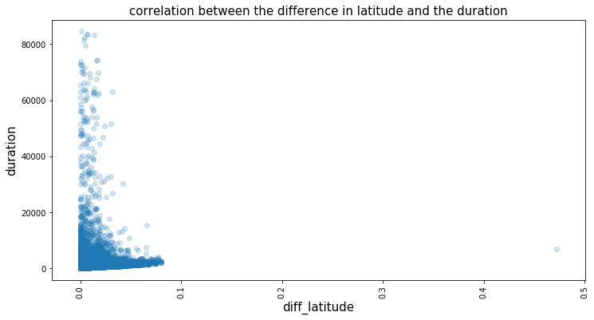

### difference in longitude and the duration of the trip are weakly correlated. The correlation coefficent 0.1 confirms that.

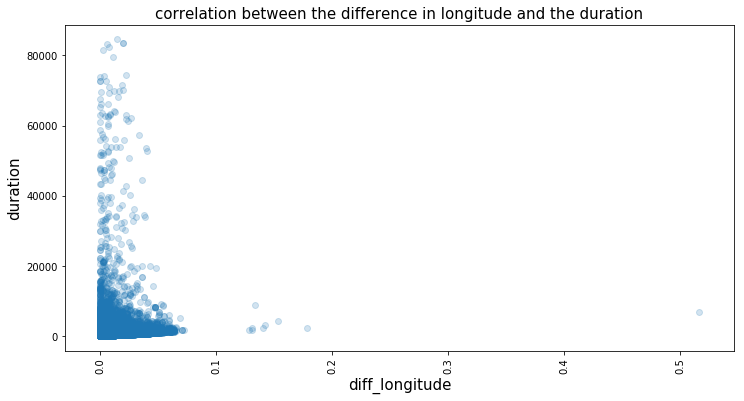

### The mean duration of each gender type is contained between 500 seconds and 800 seconds. However most of male take faster than other female which takes faster than other gender.

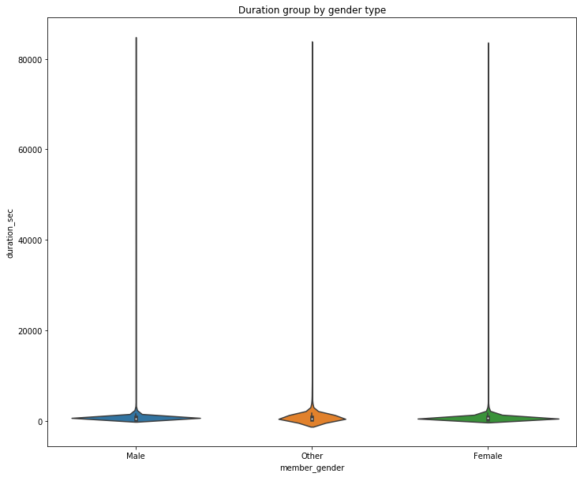

### The number of male subscribers is higher than the number of female subscribers, wich is higher than other gender and we make the same observation for the number of custumers per gender.

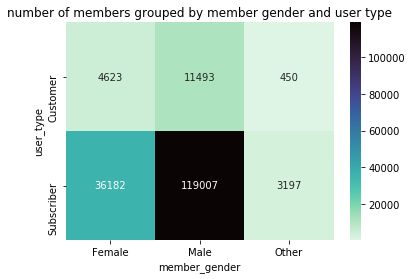

### Only the subscribers have the possibility to make bike share for all trip. However the number of subscriber having not bike share for all trip is higher than the number of customer having not bike share for all trip.

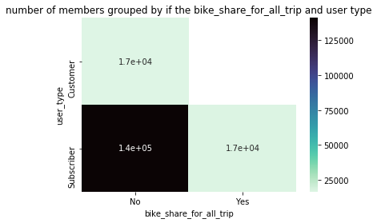